# Betacoronavirus link prediction via Elmasri et al. approach

Maxwell J. Farrell

April 30 2020

```r
# devtools::install_github("melmasri/HPprediction")
require(HPprediction)
require(ape)
require(dplyr)
require(parallel)
```

# Data

Data downloaded April 29 2020 from VERENA google drive

```r
cov_dat <- read.csv("../Data-20200429/BatCoV-assoc.csv", as.is=T)
tree_albery <- readRDS("../Data-20200429/Full Supertree.rds")
tree_super <- read.tree("../Data-20200429/supertree_mammals.tree")
# Greg's tree is not the Fritz super tree because there are 82 species missing from the data now, not 12 as with Greg's supertree.

# Dan Becker:
# "just need to change Artibeus phaeotis” and “Hipposideros commersoni” to “Dermanura phaeotis” and “Hipposideros commersonii” to match the names in “BatCoV-assoc.csv”"

# "off the top of my head, Perimyotis subflavus could be Pipistrellus subflavus, Carollia sowelli is probably Carollia brevicauda, Dermanura tolteca is probably Artibeus toltecus, Dermanura cinerea is probably Artibues cinera

# Artibeus planirostris has sometimes been considered a subspecies of A. jamaicensis

# Triaenops afer could be Triaenops persicus (same subspecies issue)

# Myotis pilosus is prolly M. ricketti"

# "Miniopterus fuliginosus was thought to be a subspecies of Miniopterus schreibersii"

# Chaerephon pusillus = Nyctinomus pusillus, Parastrellus hesperus = Pipistrellus hesperus, Neoromicia nana = Neoromicia nanus, Tadarida plicatus = Chaerephon plicatus

tree_albery$tip.label[tree_albery$tip.label=="Artibeus_phaeotis"] <- "Dermanura_phaeotis"
tree_albery$tip.label[tree_albery$tip.label=="Hipposideros_commersoni"] <- "Hipposideros_commersonii"
tree_albery$tip.label[tree_albery$tip.label=="Pipistrellus_subflavus"] <- "Perimyotis_subflavus"
tree_albery$tip.label[tree_albery$tip.label=="Carollia_brevicauda"] <- "Carollia_sowelli"
tree_albery$tip.label[tree_albery$tip.label=="Artibeus_toltecus"] <- "Dermanura_tolteca"

tree_albery$tip.label[tree_albery$tip.label=="Artibeus_cinera"] <- "Dermanura_cinerea"
# Artibeus_cinera not in tree

# tree_albery$tip.label[tree_albery$tip.label=="Myotis_ricketti"] <- "Myotis_pilosus"
# Can't do this because both myotis rickettii and pyotis pilosus are both in the data..

tree_albery$tip.label[tree_albery$tip.label=="Nyctinomus_pusillus"] <- "Chaerephon_pusillus"
# Nyctinomus_pusillus not in tree

tree_albery$tip.label[tree_albery$tip.label=="Pipistrellus_hesperus"] <- "Parastrellus_hesperus"
tree_albery$tip.label[tree_albery$tip.label=="Neoromicia_nanus"] <- "Neoromicia_nana"
tree_albery$tip.label[tree_albery$tip.label=="Chaerephon_plicatus"] <- "Tadarida_plicatus"

# Formatting host names to match phylogeny
cov_dat$host_species <- gsub(" ","_",cov_dat$host_species)

# Subspecies collapsed in data
cov_dat$host_species[cov_dat$host_species=="Artibeus_planirostris"] <- "Artibeus_jamaicensis"
cov_dat$host_species[cov_dat$host_species=="Triaenops_afer"] <- "Triaenops_persicus"
cov_dat$host_species[cov_dat$host_species=="Miniopterus_fuliginosus"] <- "Miniopterus_schreibersii"
cov_dat$host_species[cov_dat$host_species=="Myotis_pilosus"] <- "Myotis_ricketti"

# length(unique(cov_dat$host_species))#261
# length(tree_albery$tip.label)#5020
setdiff(cov_dat$host_species,tree_albery$tip.label) #4
```

```
#> [1] "Chaerephon_pusillus" "Carollia_brevicauda" "Chaerephon_plicatus"
#> [4] "Dermanura_cinerea"
```

```r
# Creating binary interaction matrix
com <- table(cov_dat$host_species, cov_dat$virus_genus)
com[com>1] <- 1
com <- as.matrix(unclass(com), nrow=nrow(com), ncol=ncol(com))

# testing: merge the trees and interaction matrices
dat <- network_clean(com, tree_albery, 'full')
####################################################################
# merging hp3 with BatCov at viral genus level
hp3 <- read.csv("../Data-20200429/HP3-associations.csv", as.is=T)

length(unique(hp3$hHostNameFinal))#754
```

```
#> [1] 754
```

```r
length(intersect(hp3$hHostNameFinal,tree_albery$tip.label))#715
```

```
#> [1] 715
```

```r
length(intersect(hp3$hHostNameFinal,tree_super$tip.label))#753
```

```
#> [1] 753
```

```r
setdiff(hp3$hHostNameFinal,tree_super$tip.label)# Felis_concolor
```

```
#> [1] "Felis_concolor"
```

```r
tree_super$tip.label[grep("concolor",tree_super$tip.label)]
```

```
#> [1] "Puma_concolor"
```

```r
tree_super$tip.label["Puma_concolor"] <- "Felis_concolor"

# create hp3 with viruses set to genus level
virus_tax <- read.csv("../Data-20200429/HP3-viruses.csv", as.is=T)
hp3_genera <- left_join(hp3, virus_tax)
hp3_genera <- subset(hp3_genera, select=c(hHostNameFinal,vGenus,DetectionMethod,DetectionQuality))
names(hp3_genera)[1:2] <- c("host_species","virus_genus")

# join and remove double counted hp3 interactions
dat_full <- full_join(cov_dat[cov_dat$origin=="Anthony",], hp3_genera)
setdiff(dat_full$host_species,tree_super$tip.label)# 75
```

```
#>  [1] "Hipposideros_vittatus"      "Hipposideros_ruber"
#>  [3] "Miniopterus_magnater"       "Myotis_ricketti"
#>  [5] "Nyctalus_plancyi"           "Pipistrellus_coromandra"
#>  [7] "Myotis_horsfieldii"         "Rhinolophus_rex"
#>  [9] "Hipposideros_pratti"        "Myotis_davidii"
#> [11] "Chaerephon_pumilus"         "Miniopterus_natalensis"
#> [13] "Mystacina_tuberculata"      "Hipposideros_gigas"
#> [15] "Triaenops_persicus"         "Sturnira_erythromos"
#> [17] "Lichonycteris_obscura"      "Rhinolophus_shameli"
#> [19] "Rhinolophus_coelophyllus"   "Hipposideros_lekaguli"
#> [21] "Myotis_longipes"            "Scotophilus_dinganii"
#> [23] "Mesophylla_macconnelli"     "Scotophilus_leucogaster"
#> [25] "Mops_condylurus"            "Scotophilus_nux"
#> [27] "Miniopterus_australis"      "Rhinolophus_megaphyllus"
#> [29] "Myotis_macropus"            "Rhinopoma_hardwickii"
```

[output cut: 23 more lines]

```r
setdiff(dat_full$host_species,tree_albery$tip.label)# 40
```

```
#>  [1] "Chaerephon_plicatus"      "Aethomys_namaquensis"
#>  [3] "Akodon_paranaensis"       "Alopex_lagopus"
#>  [5] "Artibeus_phaeotis"        "Artibeus_planirostris"
#>  [7] "Artibeus_toltecus"        "Bos_gaurus"
#>  [9] "Bos_mutus"                "Bubalus_arnee"
#> [11] "Canis_familiaris"         "Capra_aegagrus"
#> [13] "Carollia_brevicauda"      "Cervus_timorensis"
#> [15] "Choeropsis_liberiensis"   "Equus_quagga"
#> [17] "Felis_concolor"           "Handleyomys_alfaroi"
#> [19] "Herpestes_sanguineus"     "Hylaeamys_laticeps"
#> [21] "Hylaeamys_megacephalus"   "Lama_pacos"
#> [23] "Mico_leucippe"            "Miniopterus_fuliginosus"
#> [25] "Myotis_pilosus"           "Nephelomys_albigularis"
#> [27] "Ovis_orientalis"          "Physeter_macrocephalus"
#> [29] "Pipistrellus_hesperus"    "Pipistrellus_subflavus"
#> [31] "Procolobus_badius"        "Procolobus_rufomitratus"
#> [33] "Pseudalopex_gymnocercus"  "Pseudalopex_vetulus"
#> [35] "Rhinolophus_hildebrandti" "Sooretamys_angouya"
#> [37] "Tadarida_condylura"       "Tadarida_plicata"
#> [39] "Tadarida_pumila"          "Tragelaphus_oryx"
```

```r
com_full <- table(dat_full$host_species, dat_full$virus_genus)
com_full[com_full>1] <- 1
com_full <- as.matrix(unclass(com_full), nrow=nrow(com_full), ncol=ncol(com_full))

# merge the trees and interaction matrices
dat_full <- network_clean(com_full, tree_albery, 'full')

# tree_super doesn't seem to work well - multi2dierror
```

# Plotting interaction matrices

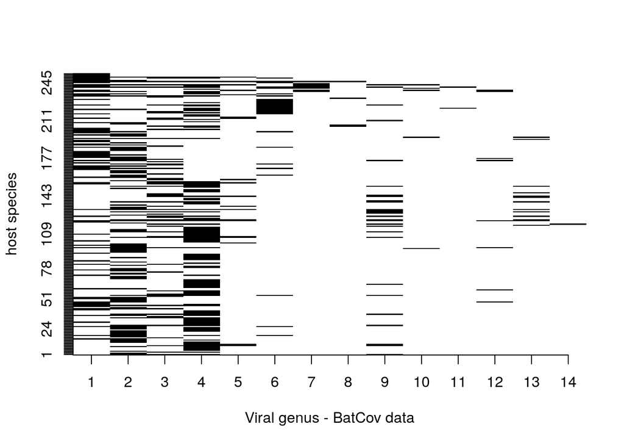

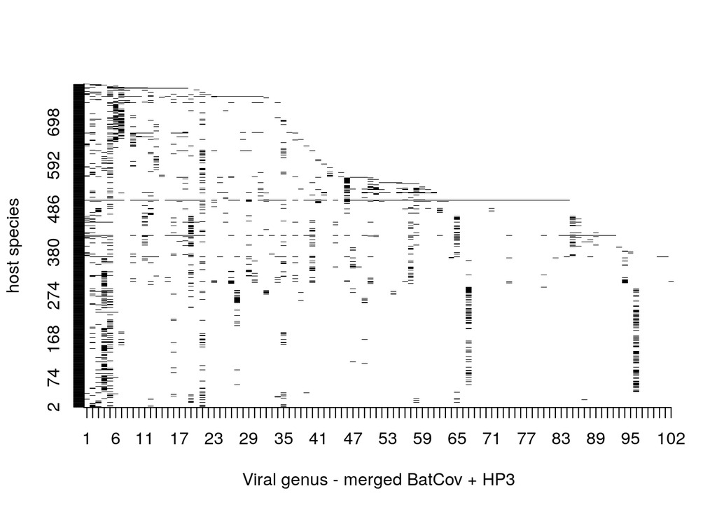

# Models on BatCoV data

## Elmasri Phylogeny only model on BatCoV data

```r
## General variables
MODEL = 'distance'                       # full, distance or affinity
SLICE = 1000                          # no of iterations
NO.CORES = 3                         # maximum cores to use
COUNT = TRUE                         # TRUE = count data, FALSE = year of first pub.
ALPHA.ROWS = 0.3                     # hyperparameter for prior over rows affinity, effective under affinity and full models only
ALPHA.COLS = 0.3                     # hyperparameter for prior over columns affinity, effective under affinity and full models only

## preparing tree and com
cleaned <- dat
com <- cleaned$Z                         # cleaned binary interaction matrix
tree <- cleaned$tree                     # cleaned tree
```

```r
## indexing 5-folds of interactions
folds <- cross.validate.fold(com, n = 10, min.per.col=1)

# returns a matrix of 3 columns (row, col, group), (row, col) correspond to Z, group to the CV group
tot.gr <- length(unique(folds[,'gr']))   # total number of CV groups

## A loop to run over all CV groups
res <- mclapply(1:tot.gr, function(x, folds, Z, tree, slice, model.type, ALPHA.ROWS, ALPHA.COLS){

    ## Analysis for a single fold
    Z.train = Z
    Z.train[folds[which(folds[,'gr']==x),c('row', 'col')]]<-0

    ## running the model of interest
    obj = network_est(Z.train, slices=slice, tree=tree, model.type=model.type,
                      a_y = ALPHA.ROWS, a_w = ALPHA.COLS)

    P = sample_parameter(obj$param, model.type, Z.train, tree)
    Eta = if(is.null(obj$param$eta)) 0 else mean(obj$param$eta)

    ## order the rows in Z.test as in Z.train
    roc = rocCurves(Z, Z.train, P, plot=FALSE, bins=400, all=FALSE)
    tb  = ana.table(Z, Z.train, P, roc,  plot=FALSE)
    roc.all = rocCurves(Z, Z.train, P=P, plot=FALSE, bins=400, all=TRUE)
    tb.all  = ana.table(Z, Z.train, P, roc.all, plot=FALSE)

    list(param=list(P=P, Eta = Eta), tb = tb,
         tb.all = tb.all, FPR.all = roc.all$roc$FPR,
         TPR.all=roc.all$roc$TPR, FPR = roc$roc$FPR, TPR=roc$roc$TPR)

},
    folds=folds, Z = com, tree=tree, model.type=MODEL, slice = SLICE,
    ALPHA.ROWS = ALPHA.ROWS, ALPHA.COLS= ALPHA.COLS,
    mc.preschedule = TRUE, mc.cores = min(tot.gr, NO.CORES))

saveRDS(res,"../results/batcov_phylo_res.rds")
```

We can analyze the performance of the model via the area under the receiver operating characteristic curve (AUC), and the proportion of 1s in the original data successfully recovered.

```
#>     m.auc m.pred.held.out.ones   m.thresh m.hold.out
#> 1  0.8359             80.43478 0.05513784         46
#> 2  0.8892             93.47826 0.04511278         46
#> 3  0.8807             86.95652 0.02756892         46
#> 4  0.8398             78.26087 0.04761905         46
#> 5  0.8353             78.26087 0.06265664         46
#> 6  0.7835             80.43478 0.03508772         46
#> 7  0.8475             82.60870 0.03759398         46
#> 8  0.8461             86.95652 0.03508772         46
#> 9  0.8819             86.95652 0.03508772         46
#> 10 0.8684             85.71429 0.04511278         49
#> [1] "Model: distance, AUC: 0.850830 and percent 1 recovered from held out: 84.006211"
```

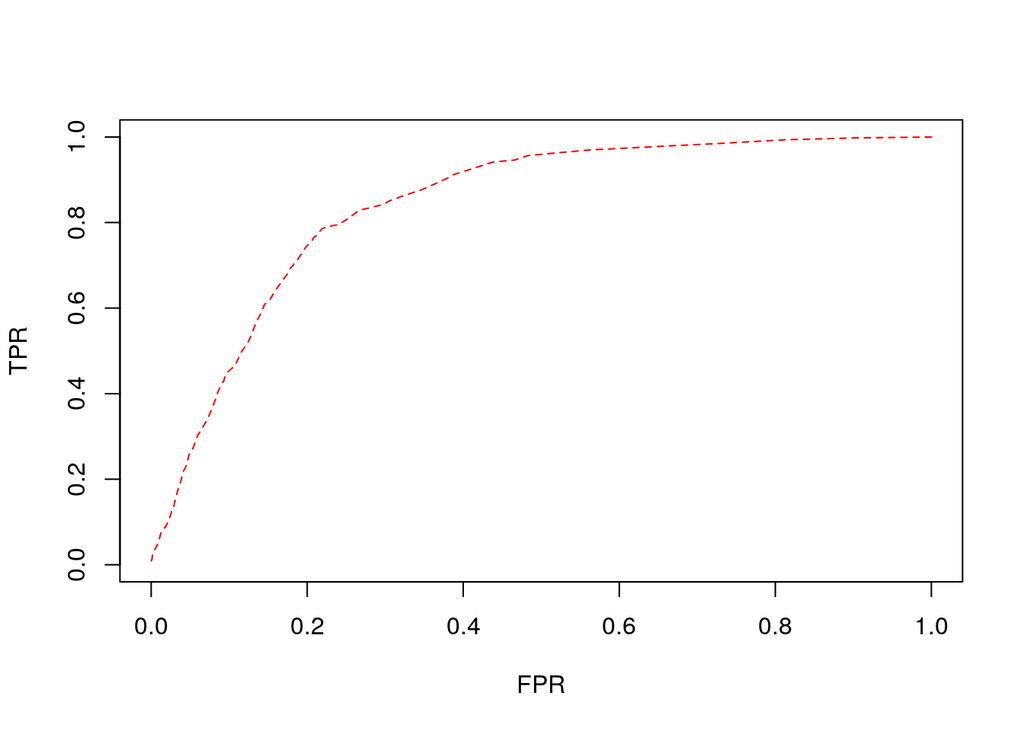

We construct the posterior probability matrix ‘P’ as the average across each fold, and look at the top undocumented interactions.

```r
## Constructing the P probability matrix from CV results
P = matrix(rowMeans(sapply(res, function(r) r$param$P)),
    nrow = nrow(cleaned$Z), ncol = ncol(cleaned$Z))

## view top undocumented interactions
topPairs(P,1*(cleaned$Z>0),topX=10)
```

```
#>                      Host         Parasite p(interaction)
#> 66     Rhinolophus_rouxii Alphacoronavirus      0.1731640
#> 73    Rhinolophus_mehelyi Alphacoronavirus      0.1731640
#> 1759       Myotis_punicus       Lyssavirus      0.1711492
#> 1757   Myotis_emarginatus       Lyssavirus      0.1678760
#> 1538 Epomophorus_labiatus       Lyssavirus      0.1668166
#> 1770       Myotis_davidii       Lyssavirus      0.1665764
#> 1753    Myotis_capaccinii       Lyssavirus      0.1663364
#> 1755      Myotis_longipes       Lyssavirus      0.1663364
#> 1756 Myotis_macrodactylus       Lyssavirus      0.1663364
#> 1768      Myotis_brandtii       Lyssavirus      0.1659659
```

```r
topPara(P, 1*(cleaned$Z>0),topX=10, para="Betacoronavirus")
```

```
#>                         Host p(interaction)
#> 1         Rhinolophus_rouxii      0.1477044
#> 2       Rhinolophus_capensis      0.1348771
#> 3   Rhinolophus_coelophyllus      0.1348771
#> 4       Rhinolophus_eloquens      0.1348771
#> 5  Rhinolophus_hildebrandtii      0.1348771
#> 6    Rhinolophus_megaphyllus      0.1348771
#> 7        Rhinolophus_shameli      0.1348771
#> 8      Rhinolophus_simulator      0.1348771
#> 9         Rhinolophus_stheno      0.1348771
#> 10     Epomophorus_wahlbergi      0.1223874
```

```r
# Save full list of predictions
P[cleaned$Z==1]<--1 # set observed interactions to -1
rownames(P) <- rownames(cleaned$Z)
colnames(P) <- colnames(cleaned$Z)
aux = melt(P)
aux = aux[order(aux$value,decreasing=TRUE),]
colnames(aux)<-c('Host', 'Parasite', 'p(interaction)')

# remove observed interactions
aux <- aux[aux[,3]!=-1,]

# replace probabilities with ranks
aux$rank <- 1:nrow(aux)
aux <- aux[,-3]
write.csv(aux, "../results/batcov_elmasri_phylo_pred.csv")

aux_betacovs <- aux[aux$Parasite=="Betacoronavirus",]
# new ranks
aux_betacovs$rank <- 1:nrow(aux_betacovs)

write.csv(aux_betacovs, "../results/batcov_elmasri_phylo_pred_betacovsOnly.csv")
```

## Elmasri Full model on BatCoV data

```r
## General variables
MODEL = 'full'                       # full, distance or affinity
SLICE = 1000                          # no of iterations
NO.CORES = 3                         # maximum cores to use
COUNT = TRUE                         # TRUE = count data, FALSE = year of first pub.
ALPHA.ROWS = 0.3                     # hyperparameter for prior over rows affinity, effective under affinity and full models only
ALPHA.COLS = 0.3                     # hyperparameter for prior over columns affinity, effective under affinity and full models only

## preparing tree and com
cleaned <- dat
com <- cleaned$Z                         # cleaned binary interaction matrix
tree <- cleaned$tree                     # cleaned tree
```

```r
## indexing 5-folds of interactions
folds <- cross.validate.fold(com, n = 10, min.per.col=1)

# returns a matrix of 3 columns (row, col, group), (row, col) correspond to Z, group to the CV group
tot.gr <- length(unique(folds[,'gr']))   # total number of CV groups

## A loop to run over all CV groups
res <- mclapply(1:tot.gr, function(x, folds, Z, tree, slice, model.type, ALPHA.ROWS, ALPHA.COLS){

    ## Analysis for a single fold
    Z.train = Z
    Z.train[folds[which(folds[,'gr']==x),c('row', 'col')]]<-0

    ## running the model of interest
    obj = network_est(Z.train, slices=slice, tree=tree, model.type=model.type,
                      a_y = ALPHA.ROWS, a_w = ALPHA.COLS)

    P = sample_parameter(obj$param, model.type, Z.train, tree)
    Eta = if(is.null(obj$param$eta)) 0 else mean(obj$param$eta)

    ## order the rows in Z.test as in Z.train
    roc = rocCurves(Z, Z.train, P, plot=FALSE, bins=400, all=FALSE)
    tb  = ana.table(Z, Z.train, P, roc,  plot=FALSE)
    roc.all = rocCurves(Z, Z.train, P=P, plot=FALSE, bins=400, all=TRUE)
    tb.all  = ana.table(Z, Z.train, P, roc.all, plot=FALSE)

    list(param=list(P=P, Eta = Eta), tb = tb,
         tb.all = tb.all, FPR.all = roc.all$roc$FPR,
         TPR.all=roc.all$roc$TPR, FPR = roc$roc$FPR, TPR=roc$roc$TPR)

},
    folds=folds, Z = com, tree=tree, model.type=MODEL, slice = SLICE,
    ALPHA.ROWS = ALPHA.ROWS, ALPHA.COLS= ALPHA.COLS,
    mc.preschedule = TRUE, mc.cores = min(tot.gr, NO.CORES))

saveRDS(res,"../results/batcov_full_res.rds")
```

We can analyze the performance of the model via the area under the receiver operating characteristic curve (AUC), and the proportion of 1s in the original data successfully recovered.

```
#>     m.auc m.pred.held.out.ones   m.thresh m.hold.out
#> 1  0.8158             82.60870 0.06265664         46
#> 2  0.8834             97.82609 0.07268170         46
#> 3  0.8124             86.95652 0.06265664         46
#> 4  0.8201             82.60870 0.06516291         46
#> 5  0.7695             76.08696 0.08270677         46
#> 6  0.8194             93.47826 0.05764411         46
#> 7  0.8120             89.13043 0.04761905         46
#> 8  0.8160             91.30435 0.05764411         46
#> 9  0.8112             84.78261 0.05263158         46
#> 10 0.8261             95.91837 0.06015038         49
#> [1] "Model: full, AUC: 0.818590 and percent 1 recovered from held out: 88.070098"
```

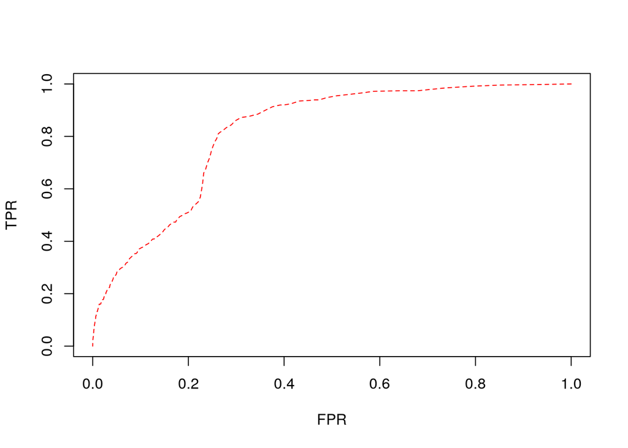

We construct the posterior probability matrix ‘P’ as the average across each fold, and look at the top undocumented interactions.

```r
## Constructing the P probability matrix from CV results
P = matrix(rowMeans(sapply(res, function(r) r$param$P)),
    nrow = nrow(cleaned$Z), ncol = ncol(cleaned$Z))

## view top undocumented interactions
topPairs(P,1*(cleaned$Z>0),topX=10)
```

```
#>                        Host         Parasite p(interaction)
#> 1534      Epomops_franqueti       Lyssavirus      0.4996083
#> 129      Dermanura_phaeotis Alphacoronavirus      0.4804976
#> 29          Pteropus_alecto Alphacoronavirus      0.4774527
#> 111   Phyllostomus_hastatus Alphacoronavirus      0.4746324
#> 16        Epomops_franqueti Alphacoronavirus      0.4562718
#> 1604   Hipposideros_armiger       Lyssavirus      0.4542174
#> 1597    Hipposideros_caffer       Lyssavirus      0.4493166
#> 638    Artibeus_jamaicensis  Betacoronavirus      0.4436180
#> 245  Myotis_septentrionalis Alphacoronavirus      0.4367094
#> 5     Cynopterus_brachyotis Alphacoronavirus      0.4272149
```

```r
topPara(P, 1*(cleaned$Z>0),topX=10, para="Betacoronavirus")
```

```
#>                     Host p(interaction)
#> 1   Artibeus_jamaicensis      0.4436180
#> 2     Scotophilus_kuhlii      0.4087187
#> 3   Glossophaga_soricina      0.4012346
#> 4        Sturnira_lilium      0.3990943
#> 5         Molossus_rufus      0.3973005
#> 6      Desmodus_rotundus      0.3927610
#> 7  Phyllostomus_hastatus      0.3871690
#> 8       Myotis_nigricans      0.3511675
#> 9       Myotis_lucifugus      0.3504333
#> 10 Tadarida_brasiliensis      0.3502822
```

```r
# Save full list of predictions
P[cleaned$Z==1]<--1 # set observed interactions to -1
rownames(P) <- rownames(cleaned$Z)
colnames(P) <- colnames(cleaned$Z)
aux = melt(P)
aux = aux[order(aux$value,decreasing=TRUE),]
colnames(aux)<-c('Host', 'Parasite', 'p(interaction)')

# remove observed interactions
aux <- aux[aux[,3]!=-1,]

# replace probabilities with ranks
aux$rank <- 1:nrow(aux)
aux <- aux[,-3]
write.csv(aux, "../results/batcov_elmasri_full_pred.csv")

aux_betacovs <- aux[aux$Parasite=="Betacoronavirus",]
# new ranks
aux_betacovs$rank <- 1:nrow(aux_betacovs)
write.csv(aux_betacovs, "../results/batcov_elmasri_full_pred_betacovsOnly.csv")
```

# Predicting with merged BatCov + HP3 (at viral genus level)

## Elmasri Phylogeny model on merged data

```r
## General variables
MODEL = 'distance'                       # full, distance or affinity
SLICE = 2000                          # no of iterations
NO.CORES = 3                         # maximum cores to use
COUNT = TRUE                         # TRUE = count data, FALSE = year of first pub.
ALPHA.ROWS = 0.3           # hyperparameter for prior over rows affinity, effective under affinity and full models only
ALPHA.COLS = 0.3           # hyperparameter for prior over columns affinity, effective under affinity and full models only

cleaned <- dat_full
com <- cleaned$Z                         # cleaned binary interaction matrix
tree <- cleaned$tree                     # cleaned tree
```

```r
## indexing 5-folds of interactions
folds <- cross.validate.fold(com, n = 10, min.per.col=1)

# returns a matrix of 3 columns (row, col, group), (row, col) correspond to Z, group to the CV group
tot.gr <- length(unique(folds[,'gr']))   # total number of CV groups

## A loop to run over all CV groups
res <- mclapply(1:tot.gr, function(x, folds, Z, tree, slice, model.type, ALPHA.ROWS, ALPHA.COLS){

    ## Analysis for a single fold
    Z.train = Z
    Z.train[folds[which(folds[,'gr']==x),c('row', 'col')]]<-0

    ## running the model of interest
    obj = network_est(Z.train, slices=slice, tree=tree, model.type=model.type,
                      a_y = ALPHA.ROWS, a_w = ALPHA.COLS)

    P = sample_parameter(obj$param, model.type, Z.train, tree)
    Eta = if(is.null(obj$param$eta)) 0 else mean(obj$param$eta)

    ## order the rows in Z.test as in Z.train
    roc = rocCurves(Z, Z.train, P, plot=FALSE, bins=400, all=FALSE)
    tb  = ana.table(Z, Z.train, P, roc,  plot=FALSE)
    roc.all = rocCurves(Z, Z.train, P=P, plot=FALSE, bins=400, all=TRUE)
    tb.all  = ana.table(Z, Z.train, P, roc.all, plot=FALSE)

    list(param=list(P=P, Eta = Eta), tb = tb,
         tb.all = tb.all, FPR.all = roc.all$roc$FPR,
         TPR.all=roc.all$roc$TPR, FPR = roc$roc$FPR, TPR=roc$roc$TPR)

},
  folds=folds, Z = com, tree=tree, model.type=MODEL, slice = SLICE,
    ALPHA.ROWS = ALPHA.ROWS, ALPHA.COLS= ALPHA.COLS,
    mc.preschedule = TRUE, mc.cores = min(tot.gr, NO.CORES))

)

saveRDS(res,"../results/hp3_batcov_genera_phylo_res.rds")
```

We can analyze the performance of the model via the area under the receiver operating characteristic curve (AUC), and the proportion of 1s in the original data successfully recovered.

[output not shown]

We construct the posterior probability matrix ‘P’ as the average across each fold, and look at the top undocumented interactions.

```r
## Constructing the P probability matrix from CV results
P = matrix(rowMeans(sapply(res, function(r) r$param$P)),
    nrow = nrow(cleaned$Z), ncol = ncol(cleaned$Z))
```

```r
## view top undocumented interactions
topPairs(P,1*(cleaned$Z>0),topX=10)
```

```
#>                           Host        Parasite p(interaction)
#> 572         Rhinolophus_rouxii Betacoronavirus     0.03291373
#> 554        Nycteris_gambiensis Betacoronavirus     0.02926766
#> 561       Rhinolophus_capensis Betacoronavirus     0.02926766
#> 563   Rhinolophus_coelophyllus Betacoronavirus     0.02926766
#> 553              Nycteris_nana Betacoronavirus     0.02848366
#> 569    Rhinolophus_megaphyllus Betacoronavirus     0.02848366
#> 564       Rhinolophus_eloquens Betacoronavirus     0.02843153
#> 566  Rhinolophus_hildebrandtii Betacoronavirus     0.02843153
#> 555          Nycteris_thebaica Betacoronavirus     0.02833096
#> 2091       Rhinolophus_sinicus       Orbivirus     0.02759921
```

```r
topPara(P, 1*(cleaned$Z>0),topX=10, para="Betacoronavirus")
```

```
#>                         Host p(interaction)
#> 1         Rhinolophus_rouxii     0.03291373
#> 2        Nycteris_gambiensis     0.02926766
#> 3       Rhinolophus_capensis     0.02926766
#> 4   Rhinolophus_coelophyllus     0.02926766
#> 5              Nycteris_nana     0.02848366
#> 6    Rhinolophus_megaphyllus     0.02848366
#> 7       Rhinolophus_eloquens     0.02843153
#> 8  Rhinolophus_hildebrandtii     0.02843153
#> 9          Nycteris_thebaica     0.02833096
#> 10        Myotis_horsfieldii     0.02688979
```

```r
# Save full list of predictions
P[cleaned$Z==1]<--1 # set observed interactions to -1
rownames(P) <- rownames(cleaned$Z)
colnames(P) <- colnames(cleaned$Z)
aux = melt(P)
aux = aux[order(aux$value,decreasing=TRUE),]
colnames(aux)<-c('Host', 'Parasite', 'p(interaction)')

# remove observed interactions
aux <- aux[aux[,3]!=-1,]

# replace probabilities with ranks
aux$rank <- 1:nrow(aux)
aux <- aux[,-3]
write.csv(aux, "../results/hp3_batcov_elmasri_phylo_pred.csv")

aux_betacovs <- aux[aux$Parasite=="Betacoronavirus",]
# new ranks
aux_betacovs$rank <- 1:nrow(aux_betacovs)
write.csv(aux_betacovs, "../results/hp3_batcov_elmasri_phylo_pred_betacovsOnly.csv")
```

## Elmasri Full model on merged data

```r
## General variables
MODEL = 'full'                       # full, distance or affinity
SLICE = 2000                          # no of iterations
NO.CORES = 3                         # maximum cores to use
COUNT = TRUE                         # TRUE = count data, FALSE = year of first pub.
ALPHA.ROWS = 0.3           # hyperparameter for prior over rows affinity, effective under affinity and full models only
ALPHA.COLS = 0.3           # hyperparameter for prior over columns affinity, effective under affinity and full models only

cleaned <- dat_full
com <- cleaned$Z                         # cleaned binary interaction matrix
tree <- cleaned$tree                     # cleaned tree
```

```r
## indexing 5-folds of interactions
folds <- cross.validate.fold(com, n = 10, min.per.col=1)

# returns a matrix of 3 columns (row, col, group), (row, col) correspond to Z, group to the CV group
tot.gr <- length(unique(folds[,'gr']))   # total number of CV groups

## A loop to run over all CV groups
res <- mclapply(1:tot.gr, function(x, folds, Z, tree, slice, model.type, ALPHA.ROWS, ALPHA.COLS){

    ## Analysis for a single fold
    Z.train = Z
    Z.train[folds[which(folds[,'gr']==x),c('row', 'col')]]<-0

    ## running the model of interest
    obj = network_est(Z.train, slices=slice, tree=tree, model.type=model.type,
                      a_y = ALPHA.ROWS, a_w = ALPHA.COLS)

    P = sample_parameter(obj$param, model.type, Z.train, tree)
    Eta = if(is.null(obj$param$eta)) 0 else mean(obj$param$eta)

    ## order the rows in Z.test as in Z.train
    roc = rocCurves(Z, Z.train, P, plot=FALSE, bins=400, all=FALSE)
    tb  = ana.table(Z, Z.train, P, roc,  plot=FALSE)
    roc.all = rocCurves(Z, Z.train, P=P, plot=FALSE, bins=400, all=TRUE)
    tb.all  = ana.table(Z, Z.train, P, roc.all, plot=FALSE)

    list(param=list(P=P, Eta = Eta), tb = tb,
         tb.all = tb.all, FPR.all = roc.all$roc$FPR,
         TPR.all=roc.all$roc$TPR, FPR = roc$roc$FPR, TPR=roc$roc$TPR)

},
  folds=folds, Z = com, tree=tree, model.type=MODEL, slice = SLICE,
    ALPHA.ROWS = ALPHA.ROWS, ALPHA.COLS= ALPHA.COLS,
    mc.preschedule = TRUE, mc.cores = min(tot.gr, NO.CORES))

)

saveRDS(res,"../results/hp3_batcov_genera_full_res.rds")
```

We can analyze the performance of the model via the area under the receiver operating characteristic curve (AUC), and the proportion of 1s in the original data successfully recovered.

```
#>     m.auc m.pred.held.out.ones    m.thresh m.hold.out
#> 1  0.8697             81.86275 0.010025063        204
#> 2  0.8549             92.64706 0.002506266        204
#> 3  0.8806             88.72549 0.012531328        204
#> 4  0.7815             67.64706 0.002506266        204
#> 5  0.8716             87.25490 0.010025063        204
#> 6  0.8741             87.74510 0.010025063        204
#> 7  0.8720             77.45098 0.007518797        204
#> 8  0.8919             90.68627 0.012531328        204
#> 9  0.8548             91.17647 0.002506266        204
#> 10 0.8649             78.64078 0.010025063        206
#> [1] "Model: full, AUC: 0.861600 and percent 1 recovered from held out: 84.383686"
```

We construct the posterior probability matrix ‘P’ as the average across each fold, and look at the top undocumented interactions.

```r
## Constructing the P probability matrix from CV results
P = matrix(rowMeans(sapply(res, function(r) r$param$P)),
    nrow = nrow(cleaned$Z), ncol = ncol(cleaned$Z))

## view top undocumented interactions
topPairs(P,1*(cleaned$Z>0),topX=10)
```

```
#>                  Host         Parasite p(interaction)
#> 41544      Sus_scrofa       Lyssavirus      0.4762207
#> 285      Homo_sapiens Alphacoronavirus      0.4636213
#> 371        Bos_taurus Alphacoronavirus      0.3634963
#> 25577  Macaca_mulatta       Flavivirus      0.3579032
#> 41397  Macaca_mulatta       Lyssavirus      0.3324029
#> 25599 Pan_troglodytes       Flavivirus      0.3172355
#> 9072       Bos_taurus  Betacoronavirus      0.3133562
#> 5117       Bos_taurus       Arenavirus      0.3086059
#> 52618      Sus_scrofa        Orbivirus      0.3027104
#> 41419 Pan_troglodytes       Lyssavirus      0.3001305
```

```r
topPara(P, 1*(cleaned$Z>0),topX=10, para="Betacoronavirus")
```

```
#>                 Host p(interaction)
#> 1         Bos_taurus      0.3133562
#> 2         Sus_scrofa      0.2951467
#> 3         Ovis_aries      0.2451110
#> 4       Mus_musculus      0.2069658
#> 5     Equus_caballus      0.2048132
#> 6       Capra_hircus      0.1815392
#> 7     Macaca_mulatta      0.1776442
#> 8    Pan_troglodytes      0.1569356
#> 9      Rattus_rattus      0.1519127
#> 10 Rattus_norvegicus      0.1492438
```

```r
# Save full list of predictions
P[cleaned$Z==1]<--1 # set observed interactions to -1
rownames(P) <- rownames(cleaned$Z)
colnames(P) <- colnames(cleaned$Z)
aux = melt(P)
aux = aux[order(aux$value,decreasing=TRUE),]
colnames(aux)<-c('Host', 'Parasite', 'p(interaction)')

# remove observed interactions
aux <- aux[aux[,3]!=-1,]

# replace probabilities with ranks
aux$rank <- 1:nrow(aux)
aux <- aux[,-3]
write.csv(aux, "../results/hp3_batcov_elmasri_full_pred.csv")

aux_betacovs <- aux[aux$Parasite=="Betacoronavirus",]
# new ranks
aux_betacovs$rank <- 1:nrow(aux_betacovs)
write.csv(aux_betacovs, "../results/hp3_batcov_elmasri_full_pred_betacovsOnly.csv")
```

## References

Elmasri, M., Farrell, M. J., Davies, T. J., & Stephens, D. A. (2020). A hierarchical Bayesian model for predicting ecological interactions using scaled evolutionary relationships. [Annals of Applied Statistics, 14(1), 221-240.](https://projecteuclid.org/euclid.aoas/1587002672)